# Cost-effectiveness analysis for influenza vaccination with uncertainty

## Cost-effectiveness acceptability frontier (CEAF)

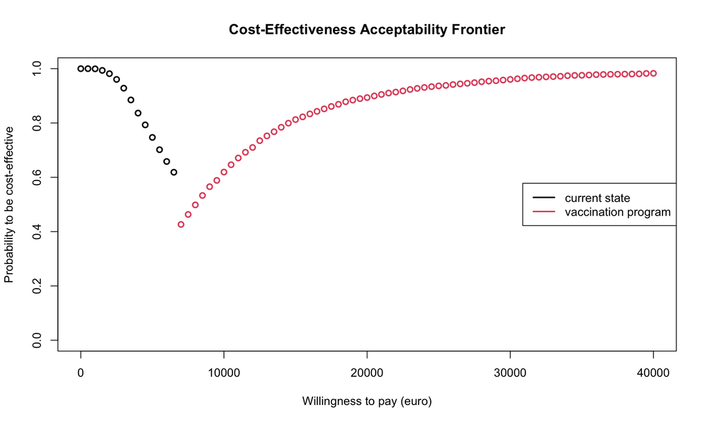

```r
plot(x = inmb_wtp_summary$wtp,
     y = inmb_wtp_summary$ceaf_proportion,
     col = inmb_wtp_summary$ceaf_intervention,
     type = 'p',
     lwd = 2,
     xlab = 'Willingness to pay (euro)',
     ylab = 'Probability to be cost-effective',
     main = 'Cost-Effectiveness Acceptability Frontier',
     ylim = 0:1,
     xlim = range(opt_wtp))
legend('right',
       c('current state','vaccination program'),
       col = 1:2,
       lwd = 2)
```

Or you can combine the CEAC and CEAF

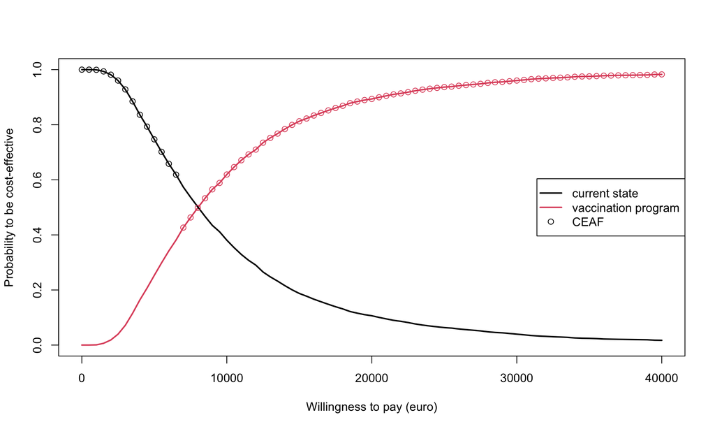

```r
# Combination of CEAC & CEAF
plot(x = inmb_wtp_summary$wtp,
     y = inmb_wtp_summary$ceac,
     type = 'l',
     lwd = 2,
     col = 2,
     xlab = 'Willingness to pay (euro)',
     ylab = 'Probability to be cost-effective',
     main = '',
     ylim = 0:1)
lines(x = inmb_wtp_summary$wtp,
      y = 1 - inmb_wtp_summary$ceac,
      type = 'l',
      col = 1,
      lwd = 2)
points(x = inmb_wtp_summary$wtp,
       y = inmb_wtp_summary$ceaf_proportion,
       col = inmb_wtp_summary$ceaf_intervention)
legend('right',
       c('current state', 'vaccination program', 'CEAF'),
       col = c(1, 2, 1),
       lwd = c(2, 2, NA),
       pch = c(NA, NA, 1))
```

## EVPI

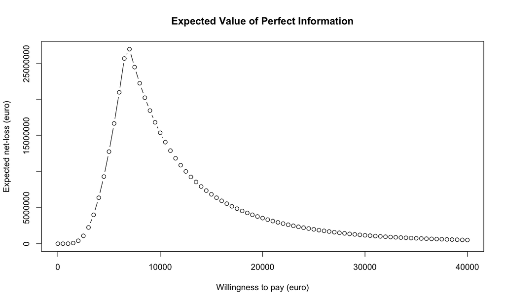

```r
plot(x = inmb_wtp_summary$wtp,
     y = inmb_wtp_summary$net_loss,
     type = 'b',
     xlab = 'Willingness to pay (euro)',
     ylab = 'Expected net-loss (euro)',
     main = "Expected Value of Perfect Information")
```

## EVPPI

If we are interested in the EVPPI, hence per individual parameter of the influenza model above, we can adopt the GAM approximation using the calculated incremental cost and benefit with all sampled parameter values.

```r
# load package for GAM
library(mgcv)

# incremental QALY gain and costs
# QALY_gained_disc
# incr_total_cost

# combine input parameters with uncertainty
model_param = data.frame(force_of_infection       = force_of_infection,
                         p_hosp                   = p_hosp,
                         life_expectancy          = life_expectancy,
                         hosp_case_fatality_ratio = hosp_case_fatality_ratio,
                         cost_per_hosp_case       = cost_per_hosp_case,
                         cost_per_non_hosp_case   = cost_per_non_hosp_case,
                         vaccine_efficacy         = vaccine_efficacy,
                         delivery_cost_per_dose   = delivery_cost_per_dose,
                         QALYloss_hosp_case       = QALYloss_hosp_case,
                         QALYloss_non_hosp_case   = QALYloss_non_hosp_case)

# specify the number of WTP and parameter values
num_param = ncol(model_param)
num_wtp   = length(opt_wtp)

# initiate matrix to store EVPPI values
evppi = matrix(0, num_wtp, num_param)

# run over all WTP levels
for(j in 1:length(opt_wtp)){

  # set WTP threshold
  k = opt_wtp[j]

  # calculate INMB
  inmb_sample = (QALY_gained_disc * k) - incr_total_cost

  # approximate NL for each parameter value
  for(i in 1:num_param){

    model     = gam(inmb_sample ~ model_param[, i])
    g.hat_new = model$fitted

    perfect.info = mean(pmax(g.hat_new, 0))
    baseline     = pmax(mean(g.hat_new), 0)

    ## estimate EVPPI
    evppi[j, i] = round(perfect.info - baseline, digits = 4)
  }
}

# add column names
colnames(evppi) = colnames(model_param)
```

Explore EVPPI

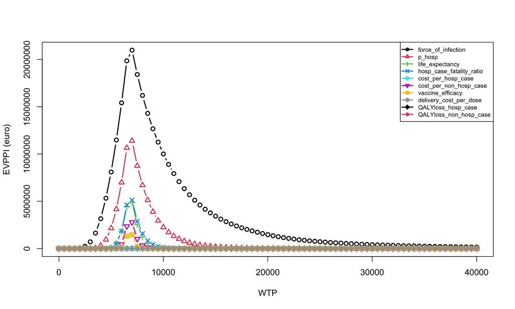

```r
# if all EVPPI values are 0, exclude parameter
evppi_edit = evppi[, colSums(evppi, na.rm = T) > 0]

# start with empty plot, and add EVPPI one by one
plot(x = range(opt_wtp),
     y = range(evppi_edit),
     col = 0,
     xlab = "WTP",
     ylab = "EVPPI (euro)")
for(i in 1:ncol(evppi_edit)){
  lines(x = opt_wtp,
        y = evppi_edit[, i],
        type = 'b',
        lwd = 2,
        col = i,
        pch = i)
}
legend('topright',
       colnames(model_param),
       col = 1:num_param,
       pch = 1:num_param,
       lwd = 2,
       cex = 0.7)
```

# Present CEA (using the `BCEA` package).

If `BCEA` package is not installed yet, you can do so by

```r
if(!"BCEA" %in% installed.packages()){
        install.packages('BCEA')
}
```

Once installed, you have to load the package(s) using

```r
library('BCEA')
```

1. Run the `bcea()`function to obtain the cost-effectiveness plane, the expected incremental net monetary benefit (INMB), the cost-effectiveness acceptability curve (CEAC) and the expected value for perfect information (EVPI):

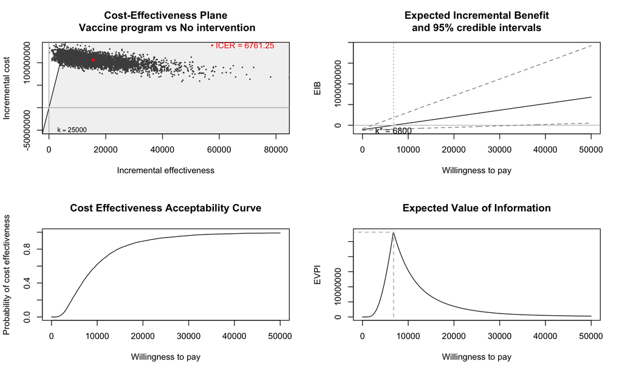

```r
# inspect the documentation of the 'bcea()' function: ?bcea

# Specify a matrix containing the clinical effectiveness for each intervention being considered.
# note: this needs to be specified as health gain (i.e. negative health loss)
ce_effects = cbind(-comparator_QALYloss_disc, -program_QALYloss_disc)


# Specify a matrix containing the cost for each intervention being considered.
# note: this needs to be specified as health gain (i.e. negative health loss)
ce_cost = cbind(comparator_total_cost, program_total_cost)

# Define the labels to be associated with each intervention.
interventions = c("No intervention", "Vaccine program")

# Run the 'bcea()' function
m = bcea(eff          = ce_effects,
         cost         = ce_cost,
         ref          = 2, # the column of eff and cost considered to be the reference strategy.
         interventions = interventions,
         plot         = T) # ref specifies to compare 'Vaccine program' to 'No intervention'
```

2. Which decision should we take, given current information and for a range of WTP values? Print the summary of the `bcea()` function:

```r
summary(m, wtp = 10000)
```

```
##
## Cost-effectiveness analysis summary
##
## Reference intervention:  Vaccine program
## Comparator intervention: No intervention
##
## Optimal decision: choose No intervention for k < 6800 and Vaccine program for k >= 6800
##
##
## Analysis for willingness to pay parameter k = 10000
##
##                 Expected net benefit
## No intervention           -356233083
## Vaccine program           -305428174
##
##                                         EIB   CEAC   ICER
## Vaccine program vs No intervention 50804909 0.6192 6761.2
##
## Optimal intervention (max expected net benefit) for k = 10000: Vaccine program
##
## EVPI 15405832
```

3. How much evidence is there in favour of the decision, for a range of WTP values? Look at the CEAC and CEAF.

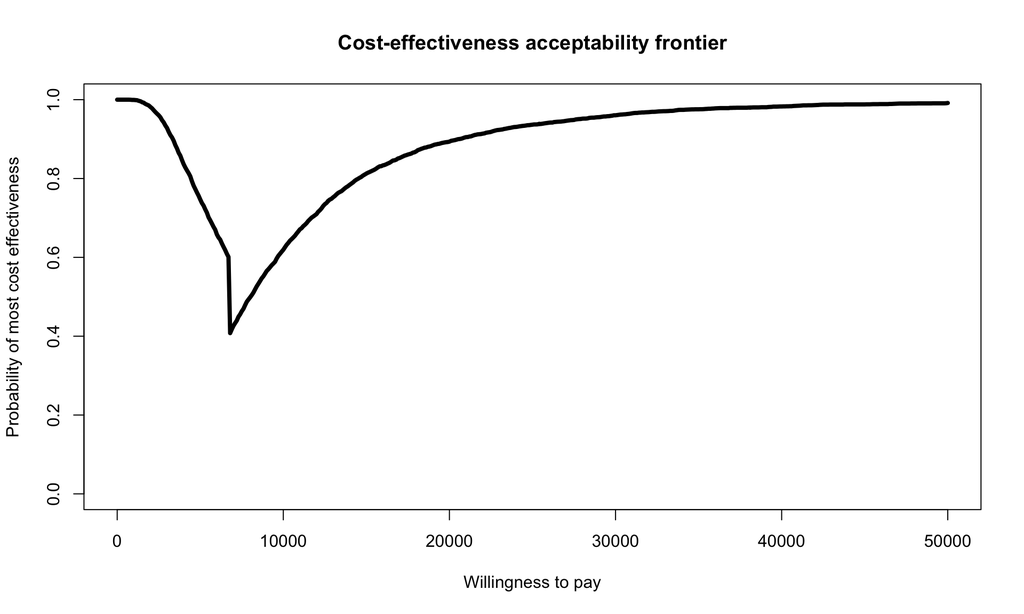

```r
m_ceaf = multi.ce(m)
ceaf.plot(m_ceaf) # uses base plot
```

4. Is there value in further research? Look at the EVPI graph and summary above.

# EVPPI

The BCEA package allows to calculate the expected value of partially perfect information for parameter subsets.

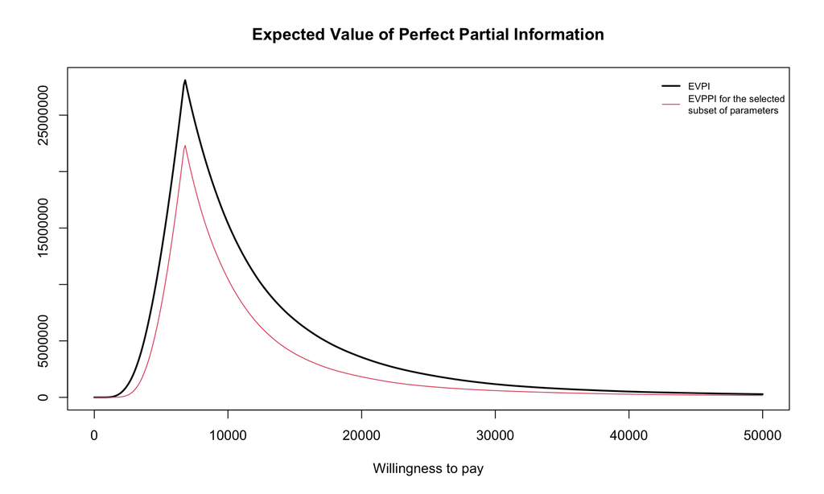

```r
# combine input parameters with uncertainty
model_param = data.frame(force_of_infection     = force_of_infection,
                         QALYloss_non_hosp_case = QALYloss_non_hosp_case)

inp = createInputs(model_param)

# explicitly use BCEA package namespace to avoid package conflict
evppi_bcea = BCEA::evppi(m, inp$parameters, inp$mat)

plot(evppi_bcea, col = 1:2, pos = c(1, 1))
```

# Navigate

Home page — Back